# VEREP Property Analysis Report

Author

HDAdvisors

Published

November 11, 2025

## Executive Summary

This analysis examines properties properties of interest (defined in methodolgy) with fewer than 30 Sunday attendees, focusing on development potential through five key metrics: land value, zoning/density, acreage, environmental limitations, and Qualified Census Tract (QCT) status.

## Methodology

### Background and Approach

Prior to this work, The [Center for Geospatial Solutions](https://www.lincolninst.edu/centers-initiatives/center-geospatial-solutions/) at the Lincoln Institute of Land Policy developed a comprehensive parcel dataset for Virginia Episcopal Real Estate Partners (VEREP) using an automated-plus-manual verification approach. The methodology combined CGS’s [Who Owns America®](https://www.lincolninst.edu/who-owns-america) (WHOA) national parcel dataset with Diocese-specific knowledge to identify properties owned by the Episcopal Diocese of Virginia, its congregations, and related organizations.

To be able to view and query parcels owned by congregations in the Episcopal Diocese of Virginia, CGS utilized its WHOA parcel ownership dataset as a starting point. CGS created this dataset by cleaning, standardizing and combining parcel data from Regrid, additional property record data from ATTOM, and corporate entity registration data from OpenCorporates into a unified, national parcel dataset. Parcels are then assessed and classified, via an automated model created by CGS, into various ownership types. This includes a column to flag parcels, based on key word searches of the parcel owner name field, that are likely affiliated with a faith-based institution.

### Defining Ownership Parameters

The original Scope of Work defined the VEREP parcel dataset as a “dataset of parcels owned by congregations in the Episcopal Diocese of Virginia”. However, following conversations with VEREP, the scope of ownership was expanded to broadly cover “parcels of interest to VEREP”, where parcel ownership would fall into one of the following categories: * Owned by the Episcopal Diocese of Virginia * Owned by Congregations in the Episcopal Diocese of Virginia * Owned by Related Organizations * Owned by Affiliate Organizations CGS relied on VEREP and its partners to define these categories and to provide starting lists of site addresses, congregation and organization names for CGS to review.

CGS then performed a recursive parcel linkage process to identify all parcels connected through shared mailing addresses and owner names, maximizing the discovery of related property holdings across Virginia.

### HDAdvisors’s Role

HDAdvisors was hired after this comprehensive geospatial data creation and analysis work to further integrate congregation statistics.

CGS initially assumed a one-to-one relationship between parcels and congregations. However, field verification revealed that multiple congregations often share the same parcel (co-located congregations sharing worship space). This one-to-many relationship created a data structure challenge. The analysis performed in this report addresses this limitation by developing appropriate join methodologies to link congregation performance metrics (attendance, membership, pledge data) with parcel characteristics, enabling integrated spatial-statistical analysis of how congregation vitality relates to property characteristics and neighborhood context.

## Data Loading and Preparation

```r
# Read the data
verep_data <- read_csv("data/verep040725.csv")
codebook <- read_csv("data/CGS_VEREP_AppendixD_Codebook.xlsx.csv")

# Read congregation attendance data
congregation_data <- read_csv("data/congregation.csv")
```

### Join Attendance Data

```r
# Prepare attendance data with most recent year (2023) and average

attendance_data <- congregation_data |>
  select(
    quickref,
    congregation_name = name,
    short_name,
    attendance_2023 = f2023_sunday_attendance,
    attendance_avg,
    members_2023 = f2023_members_this_year,
    plate_pledge_2023 = f2023_plate_and_pledge,
    attendance_pctinc,
    dio_reg
  )

# Join property data with attendance data
verep_data <- verep_data |>
  left_join(
    attendance_data,
    by = c("congr_name" = "quickref")
  )
```

**Join Results**

- Total properties: 790
- Properties matched to congregation: 497
- Properties with attendance data: 465

## Filtering Criteria

We focus our analysis on properties with fewer than 30 Sunday attendees in 2023.

```r
analysis_subset <- verep_data |>
  filter(
    !is.na(attendance_2023) &
      attendance_2023 < 30
  )
```

**Properties included:** 121 properties from 48 unique congregations.

```r
congregations_under30 <- analysis_subset |>
  filter(!is.na(congr_name)) |>
  distinct(congr_name, attendance_2023, congregation_name) |>
  arrange(attendance_2023)

congregations_under30 |>
  gt() |>
  cols_label(
    congr_name = "Quick Reference",
    congregation_name = "Congregation Name",
    attendance_2023 = "2023 Attendance"
  ) |>
  tab_style(
    style = list(
      cell_fill(color = "#f8f9fa")
    ),
    locations = cells_body(rows = seq(2, nrow(congregations_under30), 2))
  ) |>
  tab_style(
    style = cell_text(
      weight = "bold",
      color = hda_colors["blue"]
    ),
    locations = cells_column_labels()
  ) |>
  tab_options(
    table.font.size = 11
  )
```

Table 1: Congregations with <30 Sunday Attendees

| Quick Reference | 2023 Attendance | Congregation Name |
| --- | --- | --- |
| Good Shepherd-of-the-Hills (Free Union) | 0 | Good Shepherd-of-the-Hills |
| St Asaphs Church (Bowling Green) | 0 | St Asaphs Church |
| Meade Memorial Church (White Post) | 0 | Meade Memorial Church |
| St Pauls Church (Baileys Crossroads) | 0 | St Pauls Church |
| St Lukes Church (Remington) | 0 | St Lukes Church |
| St Pauls on the Hill Church (Winchester) | 0 | St Pauls on the Hill Church |
| St Bartholomews Episcopal Church (Richmond) | 0 | St Bartholomews Episcopal Church |
| St Pauls Church (West Point) | 0 | St Pauls Church |
| St Peters Church (Purcellville) | 0 | St Peters Church |
| St Georges Church (Stanley) | 0 | St Georges Church |
| St Stephen & the Good Shepherd (Elkton) | 0 | St Stephen & the Good Shepherd |
| Aquia Church (Stafford) | 0 | Aquia Church |
| Grace Church (Millers Tavern) | 0 | Grace Church |
| Immanuel Church (King and Queen Court House) | 2 | Immanuel Church |
| St Pauls Church (Shenandoah) | 9 | St Pauls Church |
| Grace Episcopal Church (Bremo Bluff) | 11 | Grace Episcopal Church |
| St Davids Church (Aylett) | 11 | St Davids Church |
| Grace Church Emmanuel Parish (Midland) | 14 | Grace Church Emmanuel Parish |
| Meade Memorial Church (Alexandria) | 15 | Meade Memorial Church |
| St Marys Church (Berryville) | 16 | St Marys Church |
| St John the Baptist Church (Charlottesville) | 18 | St John the Baptist Church |
| Church of the Good Shepherd (Bluemont) | 18 | Church of the Good Shepherd |
| St Johns Church (Columbia) | 18 | St Johns Church |
| Christ Ascension Church (Richmond) | 18 | Christ Ascension Church |
| Vauters Church (Loretto) | 19 | Vauters Church |
| Church of Our Redeemer (Aldie) | 19 | Church of Our Redeemer |
| St Francis Episcopal Church (Manakin Sabot) | 20 | St Francis Episcopal Church |
| St Johns Episcopal Church (Arlington) | 21 | St Johns Episcopal Church |
| St Patricks Anglo Vietnamese Church (Falls Church) | 21 | St Patricks Anglo Vietnamese Church |
| St Peters Church (Port Royal) | 22 | St Peters Church |
| Grace Memorial Church (Port Republic) | 22 | Grace Memorial Church |
| St Stephens Church (Catlett) | 23 | St Stephens Church |
| Calvary Episcopal Church (Hanover) | 23 | Calvary Episcopal Church |
| Emmanuel Church (King George) | 23 | Emmanuel Church |
| Christ Church (Brandy Station) | 24 | Christ Church |
| St Johns Church (King George) | 24 | St Johns Church |
| Little Fork Episcopal Church (Rixeyville) | 25 | Little Fork Episcopal Church |
| Holy Cross Korean Episcopal Church (Fairfax) | 25 | Holy Cross Korean Episcopal Church |
| St Andrews Church (Mount Jackson) | 25 | St Andrews Church |
| St James Church (Montross) | 25 | St James Church |
| Emmanuel Church (Woodstock) | 25 | Emmanuel Church |
| Holy Cross Church (Afton) | 28 | Holy Cross Church |
| All Saints Sharon Chapel (Alexandria) | 28 | All Saints Sharon Chapel |
| St Johns Episcopal Church (West Point) | 28 | St Johns Episcopal Church |
| Piedmont/Bromfield Parish (Madison) | 29 | Piedmont/Bromfield Parish |
| North Farnham Parish Church (Farnham) | 29 | North Farnham Parish Church |
| St Johns Church (Warsaw) | 29 | St Johns Church |
| St Pauls Church Nomini Grove (Warsaw) | 29 | St Pauls Church Nomini Grove |

## Analysis Results

### Land Value Analysis

```r
land_value_summary <- analysis_subset |>
  summarise(
    total_properties = n(),
    properties_with_value = sum(!is.na(lan_val)),
    mean_land_value = mean(lan_val, na.rm = TRUE),
    median_land_value = median(lan_val, na.rm = TRUE),
    min_land_value = min(lan_val, na.rm = TRUE),
    max_land_value = max(lan_val, na.rm = TRUE),
    total_land_value = sum(lan_val, na.rm = TRUE)
  )
```

The properties analyzed represent a total land value of **$27,011,671**, with a median value of **$80,000** per property.

```r
land_value_summary |>
  select(-total_properties, -properties_with_value) |>
  pivot_longer(everything(), names_to = "Metric", values_to = "Value") |>
  mutate(
    Metric = str_replace_all(Metric, "_", " ") |> str_to_title(),
    Value = dollar(Value)
  ) |>
  gt() |>
  tab_style(
    style = cell_text(
      font = "Roboto Slab",
      weight = "bold",
      color = hda_colors["blue"]
    ),
    locations = cells_column_labels()
  ) |>
  tab_options(
    table.font.names = "Lato",
    table.font.size = 11
  )
```

Table 2: Land Value Summary Statistics

| Metric | Value |
| --- | --- |
| Mean Land Value | $259,728 |
| Median Land Value | $80,000 |
| Min Land Value | $100 |
| Max Land Value | $3,567,300 |
| Total Land Value | $27,011,671 |

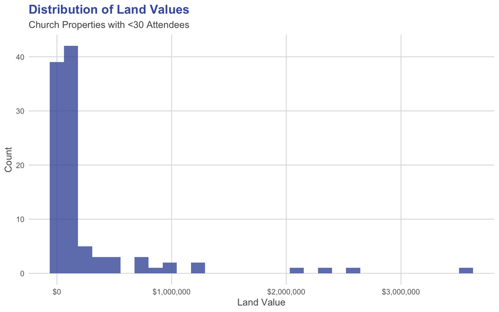

Figure 1: Distribution of Land Values

```r
analysis_subset |>
  filter(!is.na(lan_val)) |>
  ggplot(aes(x = lan_val)) +
  geom_histogram(bins = 30, fill = hda_colors["blue"], alpha = 0.8) +
  scale_x_continuous(labels = dollar_format()) +
  labs(
    title = "Distribution of Land Values",
    subtitle = "Church Properties with <30 Attendees",
    x = "Land Value",
    y = "Count"
  )
```

### Zoning & Density Analysis

```r
zoning_summary <- analysis_subset |>
  filter(!is.na(zon)) |>
  count(zon, zon_desc, sort = TRUE) |>
  mutate(percentage = n / sum(n) * 100)

zoning_type_summary <- analysis_subset |>
  filter(!is.na(zon_type)) |>
  count(zon_type, sort = TRUE) |>
  mutate(percentage = n / sum(n) * 100)
```

```r
head(zoning_summary, 10) |>
  gt() |>
  cols_label(
    zon = "Zone Code",
    zon_desc = "Description",
    n = "Count",
    percentage = "Percentage"
  ) |>
  fmt_number(columns = percentage, decimals = 1) |>
  cols_align(align = "left", columns = zon_desc) |>
  tab_style(
    style = cell_text(
      font = "Roboto Slab",
      weight = "bold",
      color = hda_colors["blue"]
    ),
    locations = cells_column_labels()
  ) |>
  tab_options(
    table.font.names = "Lato",
    table.font.size = 11
  )
```

Table 3: Top 10 Zoning Classifications

| Zone Code | Description | Count | Percentage |
| --- | --- | --- | --- |
| A1 | NA | 9 | 8.8 |
| R1 | SUBURBAN RESIDENTIAL | 9 | 8.8 |
| B-2 | GENERAL BUSINESS | 8 | 7.8 |
| RA | RURAL AGRICULTURAL | 8 | 7.8 |
| R-4 | NA | 7 | 6.9 |
| A-1 | NA | 5 | 4.9 |
| RP | NA | 5 | 4.9 |
| R-1 | NA | 3 | 2.9 |
| RA | RURAL AREAS | 3 | 2.9 |
| A1 | AGRICULTURAL | 2 | 2.0 |

### Acreage Analysis

```r
acreage_summary <- analysis_subset |>
  summarise(
    properties_with_acreage = sum(!is.na(rgisacre)),
    mean_acres = mean(rgisacre, na.rm = TRUE),
    median_acres = median(rgisacre, na.rm = TRUE),
    total_acres = sum(rgisacre, na.rm = TRUE),
    min_acres = min(rgisacre, na.rm = TRUE),
    max_acres = max(rgisacre, na.rm = TRUE)
  )

acreage_categories <- analysis_subset |>
  filter(!is.na(rgisacre)) |>
  mutate(
    acreage_category = case_when(
      rgisacre < 0.5 ~ "< 0.5 acres",
      rgisacre < 1 ~ "0.5-1 acres",
      rgisacre < 2 ~ "1-2 acres",
      rgisacre < 5 ~ "2-5 acres",
      rgisacre < 10 ~ "5-10 acres",
      TRUE ~ "10+ acres"
    ),
    acreage_category = factor(acreage_category, levels = c(
      "< 0.5 acres", "0.5-1 acres", "1-2 acres",
      "2-5 acres", "5-10 acres", "10+ acres"
    ))
  ) |>
  count(acreage_category, .drop = FALSE) |>
  mutate(percentage = n / sum(n) * 100)
```

The properties encompass a total of **338.9 acres**, with a median parcel size of **0.82 acres**.

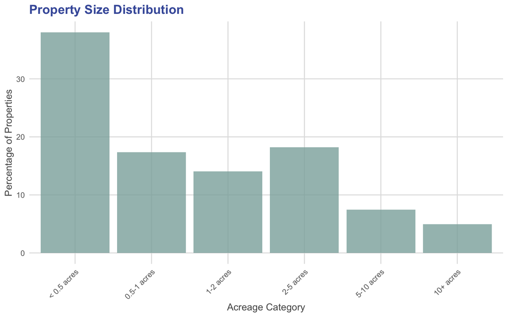

Figure 2: Acreage Distribution

```r
acreage_categories |>
  ggplot(aes(x = acreage_category, y = percentage)) +
  geom_col(fill = hda_colors["green"], alpha = 0.8) +
  geom_text(
    aes(label = sprintf("%.1f%%", percentage)),
    vjust = -0.5,
    size = 3.5,
    family = "Lato",
    color = "#555555"
  ) +
  labs(
    title = "Property Size Distribution",
    x = "Acreage Category",
    y = "Percentage of Properties"
  ) +
  theme(axis.text.x = element_text(angle = 45, hjust = 1))
```

### Environmental Limitations

```r
environmental_summary <- analysis_subset |>
  summarise(
    properties_with_wetlands = sum(wet_perc > 0, na.rm = TRUE),
    avg_wetland_coverage = mean(wet_perc, na.rm = TRUE),
    significant_wetlands = sum(wet_perc > 10, na.rm = TRUE),
    in_flood_zone = sum(!is.na(fema_fz) & fema_fz != "" & fema_fz != "X", na.rm = TRUE),
    in_high_risk_flood = sum(fema_fz %in% c("A", "AE", "AO", "AH", "V", "VE"), na.rm = TRUE),
    high_fema_risk = sum(fema_nri %in% c("Very High", "Relatively High"), na.rm = TRUE)
  )

flood_zone_summary <- analysis_subset |>
  filter(!is.na(fema_fz) & fema_fz != "") |>
  count(fema_fz, sort = TRUE) |>
  mutate(percentage = n / sum(n) * 100)
```

**Environmental Constraints**

- **6** properties located in flood zones
- **6** properties with >10% wetland coverage
- **3** properties in high-risk flood zones

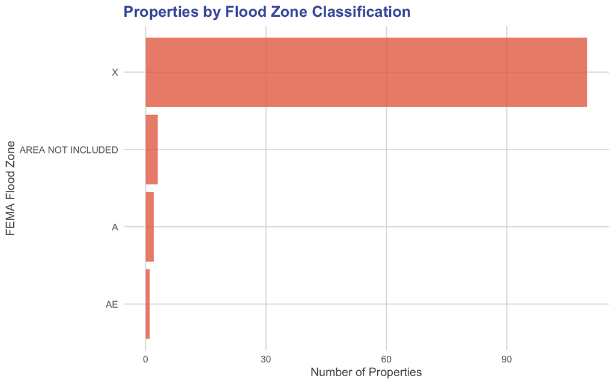

Figure 3: Flood Zone Distribution

```r
if(nrow(flood_zone_summary) > 0) {
  flood_zone_summary |>
    head(10) |>
    ggplot(aes(x = reorder(fema_fz, n), y = n)) +
    geom_col(fill = hda_colors["coral"], alpha = 0.8) +
    geom_text(
      aes(label = n),
      hjust = -0.2,
      size = 3.5,
      family = "Lato",
      color = "#555555"
    ) +
    coord_flip() +
    labs(
      title = "Properties by Flood Zone Classification",
      x = "FEMA Flood Zone",
      y = "Number of Properties"
    )
}
```

### QCT & DDA Status

```r
qct_summary <- analysis_subset |>
  summarise(
    total_properties = n(),
    in_qct = sum(qct == 1, na.rm = TRUE),
    not_in_qct = sum(qct == 0, na.rm = TRUE),
    qct_percentage = sum(qct == 1, na.rm = TRUE) / n() * 100,
    in_dda = sum(dda == 1, na.rm = TRUE),
    dda_percentage = sum(dda == 1, na.rm = TRUE) / n() * 100
  )
```

**1** properties (0.8%) are located in Qualified Census Tracts, making them eligible for enhanced LIHTC tax credits.

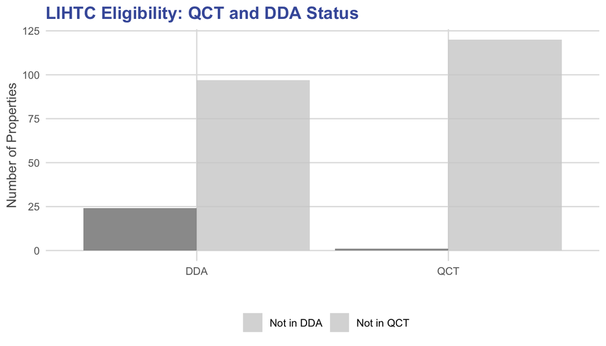

Figure 4: QCT and DDA Status

```r
tibble(
  Status = c("In QCT", "Not in QCT", "In DDA", "Not in DDA"),
  Count = c(qct_summary$in_qct, qct_summary$not_in_qct,
            qct_summary$in_dda, qct_summary$total_properties - qct_summary$in_dda),
  Type = c("QCT", "QCT", "DDA", "DDA")
) |>
  ggplot(aes(x = Type, y = Count, fill = Status)) +
  geom_col(position = "dodge", alpha = 0.8) +
  geom_text(
    aes(label = Count),
    position = position_dodge(width = 0.9),
    vjust = -0.5,
    family = "Lato",
    size = 3.5
  ) +
  scale_fill_manual(values = c(
    "In QCT" = hda_colors["blue"],
    "Not in QCT" = "#d0d0d0",
    "In DDA" = hda_colors["green"],
    "Not in DDA" = "#d0d0d0"
  )) +
  labs(
    title = "LIHTC Eligibility: QCT and DDA Status",
    x = "",
    y = "Number of Properties",
    fill = ""
  ) +
  theme(legend.position = "bottom")
```

## Development Opportunity Assessment

```r
property_profile <- analysis_subset |>
  filter(!is.na(lan_val)) |>
  mutate(
    has_environmental_constraint = (wet_perc > 10) |
      (fema_fz %in% c("A", "AE", "AO", "AH", "V", "VE")),
    developable = (rgisacre >= 1) & (!has_environmental_constraint),
    land_value_per_acre = if_else(rgisacre > 0, lan_val / rgisacre, NA_real_)
  ) |>
  select(
    uid, pid, congr_name,
    attendance_2023, members_2023, attendance_avg,
    lan_val, land_value_per_acre, rgisacre, deed_acres,
    zon, zon_desc, zon_type,
    qct, dda,
    wet_perc, fema_fz, fema_nri,
    has_environmental_constraint, developable,
    sadd, scity, scounty, sstate, szip,
    lat, lon
  ) |>
  arrange(desc(developable), desc(lan_val))

opportunity_matrix <- property_profile |>
  summarise(
    high_opportunity = sum(qct == 1 & rgisacre >= 1 & !has_environmental_constraint, na.rm = TRUE),
    medium_opportunity = sum((qct == 1 | dda == 1) & rgisacre >= 0.5 & rgisacre < 1, na.rm = TRUE),
    constrained_properties = sum(has_environmental_constraint == TRUE, na.rm = TRUE),
    small_parcels = sum(rgisacre < 0.5, na.rm = TRUE)
  )
```

### Opportunity Classification

```r
opportunity_matrix |>
  pivot_longer(everything(), names_to = "Category", values_to = "Count") |>
  mutate(
    Category = case_when(
      Category == "high_opportunity" ~ "High Opportunity",
      Category == "medium_opportunity" ~ "Medium Opportunity",
      Category == "constrained_properties" ~ "Environmentally Constrained",
      Category == "small_parcels" ~ "Small Parcels (<0.5 acres)"
    ),
    Description = case_when(
      Category == "High Opportunity" ~ "QCT + ≥1 acre + no major constraints",
      Category == "Medium Opportunity" ~ "QCT/DDA + 0.5-1 acre",
      Category == "Environmentally Constrained" ~ "Flood zones or significant wetlands",
      Category == "Small Parcels (<0.5 acres)" ~ "Limited development potential"
    )
  ) |>
  gt() |>
  tab_style(
    style = list(
      cell_fill(color = scales::alpha(hda_colors["blue"], 0.2)),
      cell_text(weight = "bold")
    ),
    locations = cells_body(rows = Category == "High Opportunity")
  ) |>
  tab_style(
    style = cell_fill(color = scales::alpha(hda_colors["yellow"], 0.2)),
    locations = cells_body(rows = Category == "Medium Opportunity")
  ) |>
  tab_style(
    style = cell_text(
      font = "Roboto Slab",
      weight = "bold",
      color = hda_colors["blue"]
    ),
    locations = cells_column_labels()
  ) |>
  tab_options(
    table.font.names = "Lato",
    table.font.size = 11
  )
```

Table 4: Development Opportunity Matrix

| Category | Count | Description |
| --- | --- | --- |
| High Opportunity | 0 | QCT + ≥1 acre + no major constraints |
| Medium Opportunity | 3 | QCT/DDA + 0.5-1 acre |
| Environmentally Constrained | 4 | Flood zones or significant wetlands |
| Small Parcels (<0.5 acres) | 41 | Limited development potential |

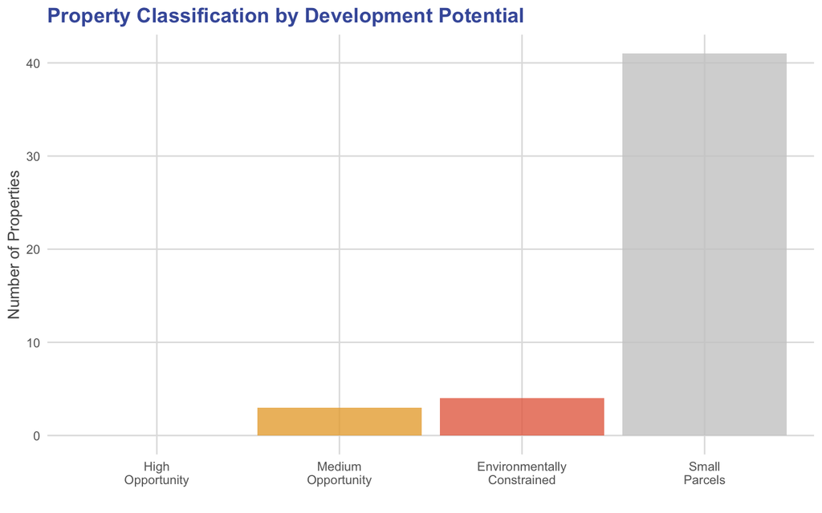

Figure 5: Development Opportunity Breakdown

```r
opportunity_matrix |>
  pivot_longer(everything(), names_to = "Category", values_to = "Count") |>
  mutate(
    Category = case_when(
      Category == "high_opportunity" ~ "High\nOpportunity",
      Category == "medium_opportunity" ~ "Medium\nOpportunity",
      Category == "constrained_properties" ~ "Environmentally\nConstrained",
      Category == "small_parcels" ~ "Small\nParcels"
    ),
    Category = factor(Category, levels = c(
      "High\nOpportunity", "Medium\nOpportunity",
      "Environmentally\nConstrained", "Small\nParcels"
    )),
    color = c(hda_colors["blue"], hda_colors["yellow"],
              hda_colors["coral"], "#cccccc")
  ) |>
  ggplot(aes(x = Category, y = Count, fill = color)) +
  geom_col(alpha = 0.8) +
  geom_text(
    aes(label = Count),
    vjust = -0.5,
    family = "Lato",
    size = 4,
    fontface = "bold"
  ) +
  scale_fill_identity() +
  labs(
    title = "Property Classification by Development Potential",
    x = "",
    y = "Number of Properties"
  ) +
  theme(legend.position = "none")
```

### Top Development Opportunities

```r
property_profile |>
  filter(developable == TRUE) |>
  select(congr_name, attendance_2023, lan_val, rgisacre, qct, scity, scounty) |>
  head(10) |>
  gt() |>
  cols_label(
    congr_name = "Congregation",
    attendance_2023 = "2023 Attendance",
    lan_val = "Land Value",
    rgisacre = "Acres",
    qct = "QCT",
    scity = "City",
    scounty = "County"
  ) |>
  fmt_currency(columns = lan_val, decimals = 0) |>
  fmt_number(columns = rgisacre, decimals = 2) |>
  fmt_integer(columns = qct) |>
  tab_style(
    style = cell_text(
      font = "Roboto Slab",
      weight = "bold",
      color = hda_colors["blue"]
    ),
    locations = cells_column_labels()
  ) |>
  tab_style(
    style = cell_fill(color = scales::alpha(hda_colors["green"], 0.15)),
    locations = cells_body(columns = qct, rows = qct == 1)
  ) |>
  tab_options(
    table.font.names = "Lato",
    table.font.size = 11
  )
```

Table 5: Properties with Highest Development Potential

| Congregation | 2023 Attendance | Land Value | Acres | QCT | City | County |
| --- | --- | --- | --- | --- | --- | --- |
| Aquia Church (Stafford) | 0 | $2,339,700 | 31.38 | 0 | AQUIA HARBOUR | STAFFORD |
| St Stephens Church (Catlett) | 23 | $136,400 | 2.36 | 0 | CATLETT | FAUQUIER |
| St Pauls on the Hill Church (Winchester) | 0 | $133,600 | 1.67 | 0 | WINCHESTER | FREDERICK |
| St Stephens Church (Catlett) | 23 | $35,900 | 8.72 | 0 | UNASSIGNED | FAUQUIER |

## Attendance Profile

```r
attendance_context <- analysis_subset |>
  filter(!is.na(attendance_2023)) |>
  summarise(
    mean_attendance = mean(attendance_2023, na.rm = TRUE),
    median_attendance = median(attendance_2023, na.rm = TRUE),
    zero_attendance = sum(attendance_2023 == 0, na.rm = TRUE),
    attendance_1_10 = sum(attendance_2023 > 0 & attendance_2023 <= 10, na.rm = TRUE),
    attendance_11_20 = sum(attendance_2023 > 10 & attendance_2023 <= 20, na.rm = TRUE),
    attendance_21_29 = sum(attendance_2023 > 20 & attendance_2023 < 30, na.rm = TRUE),
    avg_members = mean(members_2023, na.rm = TRUE),
    avg_plate_pledge = mean(plate_pledge_2023, na.rm = TRUE)
  )
```

**Attendance Summary**

Average 2023 attendance for properties in this analysis: **16.5**

The distribution shows:

- Zero attendance: 32 properties
- 1-10 attendees: 4 properties
- 11-20 attendees: 24 properties
- 21-29 attendees: 61 properties

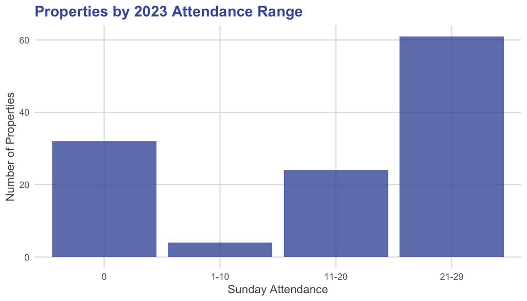

Figure 6: Attendance Distribution

```r
tibble(
  Category = c("0", "1-10", "11-20", "21-29"),
  Count = c(
    attendance_context$zero_attendance,
    attendance_context$attendance_1_10,
    attendance_context$attendance_11_20,
    attendance_context$attendance_21_29
  )
) |>
  mutate(Category = factor(Category, levels = c("0", "1-10", "11-20", "21-29"))) |>
  ggplot(aes(x = Category, y = Count)) +
  geom_col(fill = hda_colors["blue"], alpha = 0.8) +
  geom_text(
    aes(label = Count),
    vjust = -0.5,
    family = "Lato",
    size = 4
  ) +
  labs(
    title = "Properties by 2023 Attendance Range",
    x = "Sunday Attendance",
    y = "Number of Properties"
  )
```

## Conclusions

This analysis identified **0 high-opportunity properties** that combine favorable location (QCT eligibility), sufficient acreage (≥1 acre), and minimal environmental constraints. An additional **3 medium-opportunity properties** warrant further investigation.

### Key Findings

- **Total Land Value:** $27,011,671 across 121 properties
- **Total Acreage:** 338.9 acres available
- **LIHTC Eligibility:** 1 properties (0.8%) in QCT zones
- **Development Ready:** 0 properties meet all criteria for immediate development consideration

### Recommendations

1. **Priority Focus:** Concentrate initial outreach on the 0 high-opportunity properties
2. **Secondary Review:** Conduct site visits for medium-opportunity properties to assess actual constraints
3. **Congregation Support:** Develop resources for congregations to understand development options
4. **Financial Analysis:** Model pro forma scenarios for top 10 properties to determine feasibility

*Analysis completed: 2025-11-11*

*Data exported to: `verep_analysis_results.csv`*

*For PDF version, render with `quarto render document.qmd --to pdf`*